# Distribuições de Probabilidade

Jaqueline V Moreira

2024-06-12

# Binomial Distribution

**The binomial distribution is a discrete probability distribution that describes the number of successes in a fixed number of independent Bernoulli trials, each with the same probability of success. Mathematically, it is defined by the probability mass function (PMF) for k successes in n trials**

### Example

According to Statistics Canada life tables, the probability a randomly selected 90 year-old Canadian male survives for at least another year is approximately 0.82. If twenty 90-year-old Canadian males are randomly selected,

1. What is the probability exactly 18 survives for at least another year?
2. What is the probability that last than 15 survives for another year?

Successes: The man survives for at least on year Failure: The man dies within one year Since the sampling of men are random, it’s reasonable to consider them independent

Let x represent the number of men that survive for at least one year n = 20 p = 0.82

#### a) Exactly 18

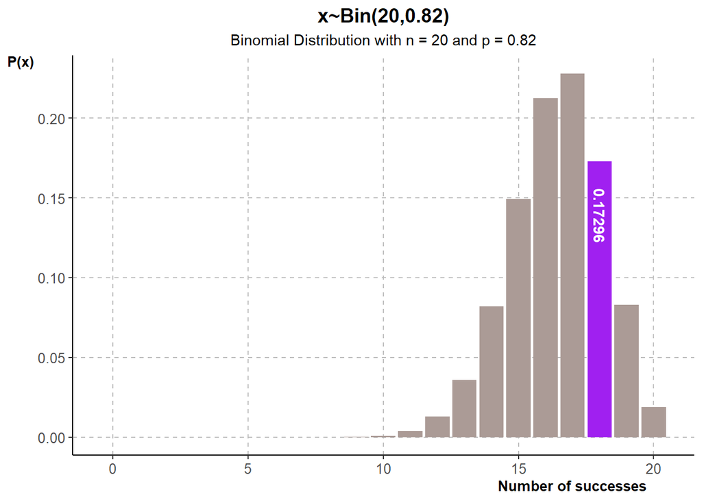

#### b) Last than 15

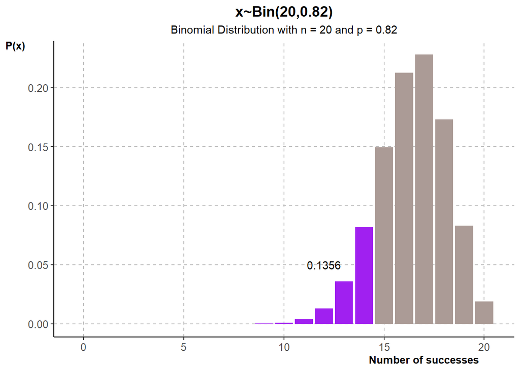

# Poisson Distribution

**A discrete distribution representing the number of events in a certain time interval** **A scenario with a constant occurring rate can be either described in terms of poisson or exponencial distribution**

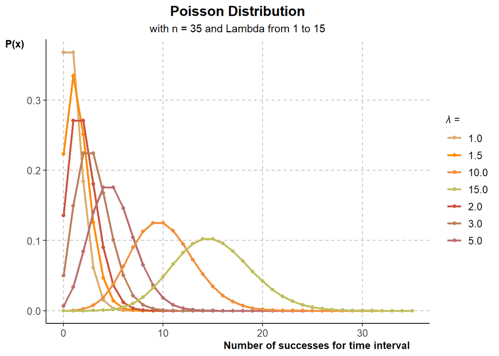

### Example

Exclusive Vines import Argentinian wine into Australia. They’ve begun advertising on Facebook to direct traffic to their website where customers can order wine online. The number of click-through sales from the ad is Poisson distributed with a mean of 12 click-through sales per day.

μ = 12 click-through sales per day E(x) = μ = λ

Find the probability of getting: a) exaclty 8 click-through sales in the first day b) at least 10 click-through sales in the first day

#### a) Exacly 8

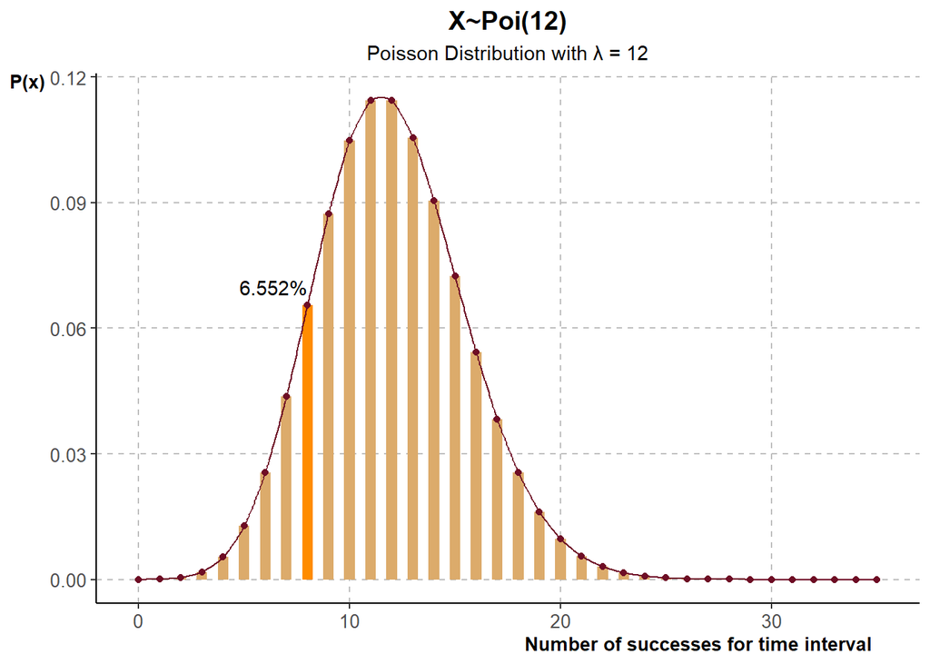

#### b) At least 10

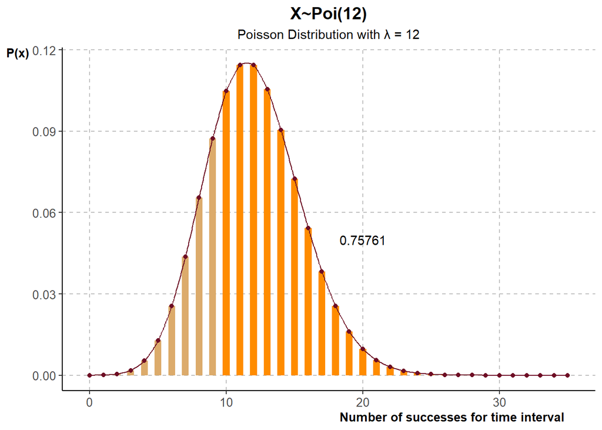

# Relationship between binomial and poisson distribution

**The Binomial Distribution tends towards Poisson distribution as:** **n tends to infinity** **p tends to zero** **Lambda stays constant and np = Lambda.**

**In other words, if the mean of a Binomial Distribution is equal to the rate of Lambda in a Poisson Distribution (np = Lambda) both distribution will convert to the same results as n increases and p decreases.**

**The Poisson Distribution can be used to provide a reasonable approximation to the Binomial Distribution if the sample is large (n>=50) and p is small (rare events with p<=0.05)**

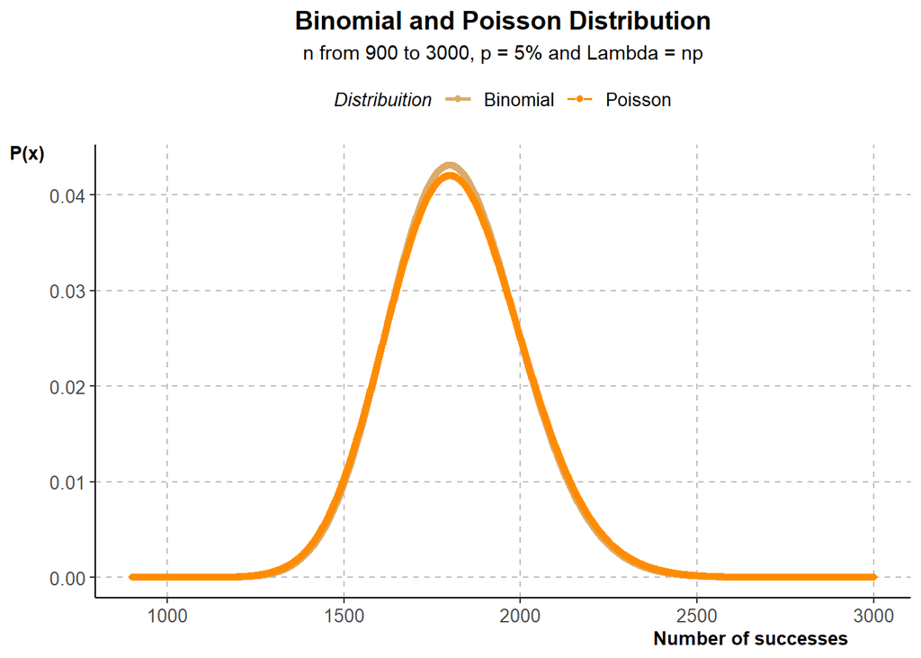

```
## [1] "X~Bin(2500,0.05)"
```

```
## [1] "P(X = 90) = 0.000144"
```

```
## [1] " and "
```

```
## [1] "X~Poi(2500*0.05)"
```

```
## [1] "P(X = 90) = 0.000183"
```

```
## [1] "Uma diferença de apenas 3.9e-05"
```

# Binomial and Poisson example

Albinism is a rare genetic disorder that affects one in 20.000 europeans. People with albinism produce little or none of the pigment melanin. In a random sample of 1.000 europeans, what is the probability that exactly 2 have albnism? In a random sampling the events can be considered independent. In this case each trial can be considered a bernoulli trial with p = 1/20000 In a Binomial distribution: n = 1000 x = 2 in a Poisson distribution: Lambda = n*p lambda = 1000*1/20000

```
## [1] "In a Binomial distribution P(X = 2) = 0.001188"
```

```
## [1] "In a Poisson distribution P(X = 2) = 0.001189"
```

```
## [1] "a difference of 1e-06"
```

# Exponential Distribution

**The exponential distribution is one of the widely used continuous distributions. It is used to model the time elapsed between events.**

Poisson = Discrete Number of events in a time interval

Exponencial = Continuous The time between two events

*The same event can be modeled as a Poisson or an Exponential distribution*

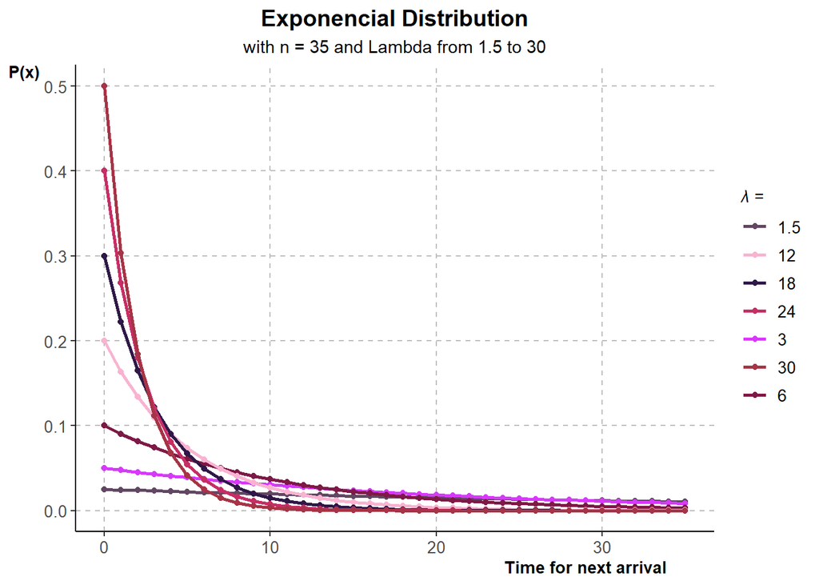

### Example

Unique visitors arrive at a certain site by a Poisson distribution at an average rate of 3 per hour. The average rate of a Poisson distribution is lambda so in this case lambda is equal to 3/hour What is the probability that the next visitor will arrive:

1. Within 15 mins
2. After 30 mins passes
3. Between 40 and 60 mins

The questions reference the time interval for the next arrival NOT THE AMOUNT OF VISITORS. In this case, the exponential distribution will be used. Lambda of 3 means that 3 visitors arrive by hour or one visitor every 20 min on average. To make the graph more intuitive, the scale will be built in terms of minutes. 3 per hour = 3/60 = 0.05 clients per minute (rate in the graph)

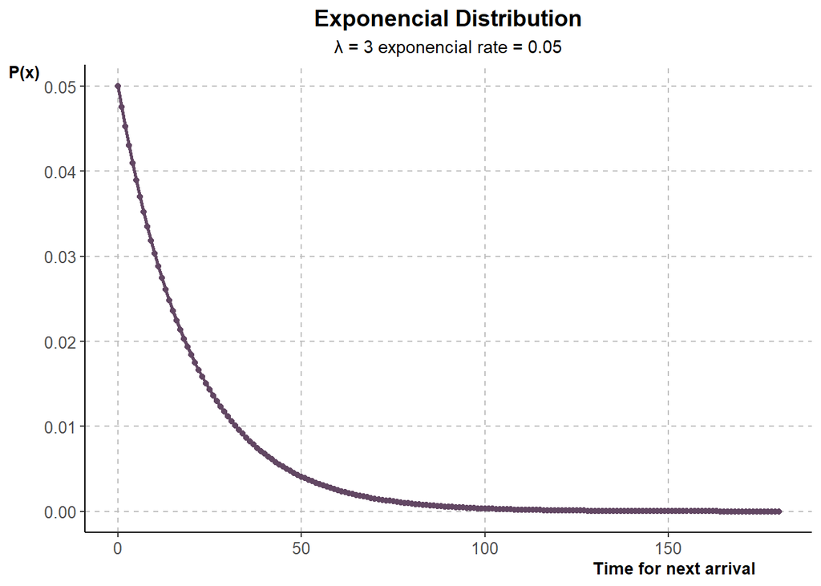

#### a) Within 15 min

[figure not shown]

```
## [1] "P(x<15) = 0.5276"
```

#### b) After 30 min

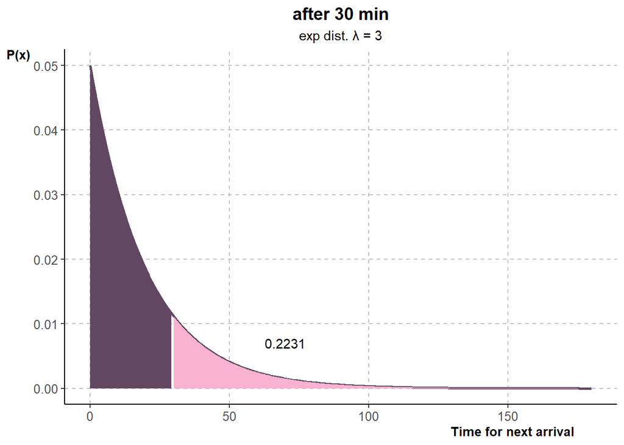

```
## [1] "P(x>30) = 0.2231"
```

#### c) Between 40 and 60 min

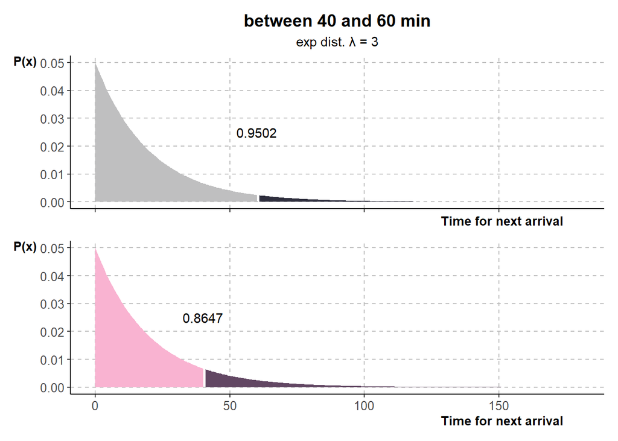

```
## [1] "P(x>40 e x<60) = 0,9502 - 0,8647"
```

```
## [1] "P(x>40 e x<60) = 0.0855"
```